# R Summer Assignment – Part 3

YOUR NAME

25 May, 2026

**Part 3: Visualizing Development Patterns**

**Estimated time:** 2-3 hours

This assignment introduces `ggplot2`, the main plotting system we will use in R. The goal is descriptive: make graphs that show trends, comparisons, and associations. Do not claim that one variable causes another.

## Why knit?

Knit regularly. A graph that appears after you run chunks manually might still fail if the document cannot run from top to bottom.

## Packages and data

```r
options(repos = c(CRAN = "https://cloud.r-project.org"))

if (!requireNamespace("tidyverse", quietly = TRUE)) {
  install.packages("tidyverse")
}

library(tidyverse)

dev <- read_csv("../data/development_indicators_2026.csv")
dictionary <- read_csv("../data/development_indicators_dictionary_2026.csv")

hks_blue <- "#1F5F83"
hks_crimson <- "#A51C30"
hks_gray <- "#6B7280"

theme_set(
  theme_minimal(base_size = 13) +
    theme(
      plot.title = element_text(face = "bold"),
      plot.subtitle = element_text(color = "gray35"),
      panel.grid.minor = element_blank()
    )
)
```

## A first line plot

A line plot is useful for trends over time. Start by filtering to one country.

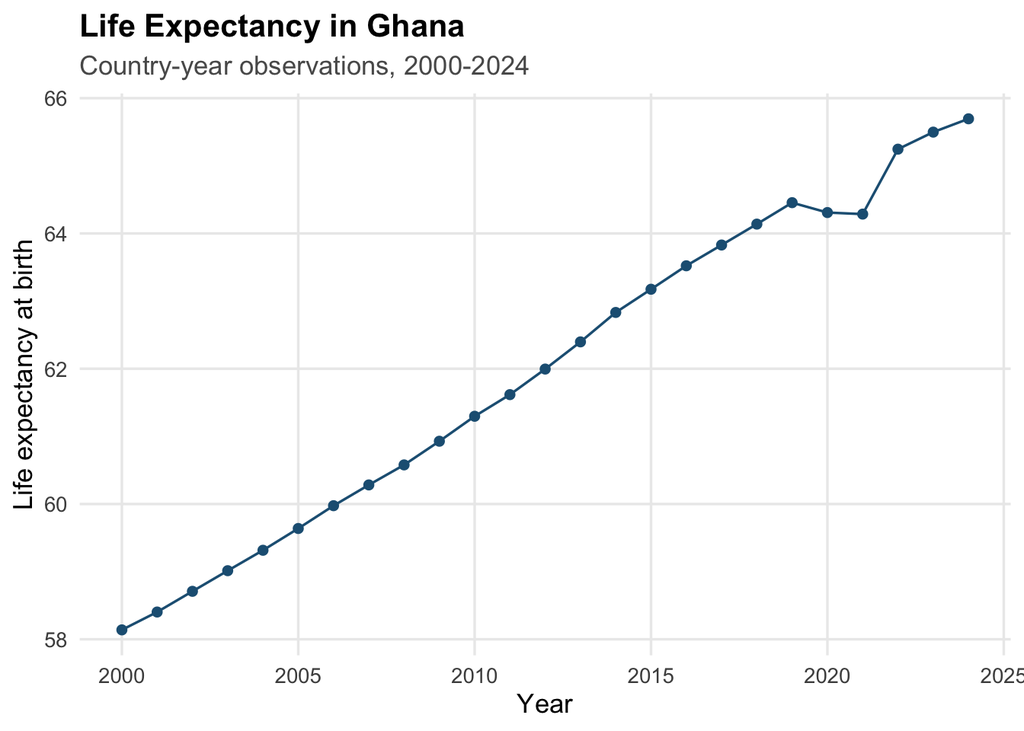

```r
ghana <- dev |>
  filter(country == "Ghana")

ghana |>
  ggplot(aes(x = year, y = life_expectancy)) +
  geom_line(color = hks_blue) +
  geom_point(color = hks_blue) +
  labs(
    x = "Year",
    y = "Life expectancy at birth",
    title = "Life Expectancy in Ghana",
    subtitle = "Country-year observations, 2000-2024"
  )
```

## Exercises 1: trends

1. Create an object for one country other than Ghana.

```r
# Write your code here.
```

2. Make a line plot of that country’s under-5 mortality over time.

```r
# Write your code here.
```

3. In one sentence, describe the trend. Is this a trend, comparison, or association?

Write your answer here:

## Comparing peer countries

You can use `%in%` to filter to several values at once.

```r
east_africa_peers <- dev |>
  filter(country %in% c("Kenya", "Rwanda", "Tanzania", "Uganda"))
```

Map color to country to compare trends.

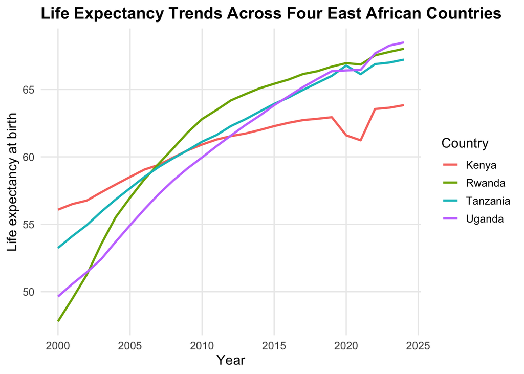

```r
east_africa_peers |>
  ggplot(aes(x = year, y = life_expectancy, color = country)) +
  geom_line(linewidth = 1) +
  labs(
    x = "Year",
    y = "Life expectancy at birth",
    color = "Country",
    title = "Life Expectancy Trends Across Four East African Countries"
  )
```

## Exercises 2: coherent peer comparison

1. Choose 3-5 countries from the same region. Use `distinct()` first if you need to check which countries are in the region.

```r
# Write your code here.
```

2. Create a line plot comparing GDP per capita over time for those countries.

```r
# Write your code here.
```

3. What is the main comparison in your graph? What is one caveat?

Write your answer here:

## Scatterplots

Scatterplots are useful for associations between two variables in the same year.

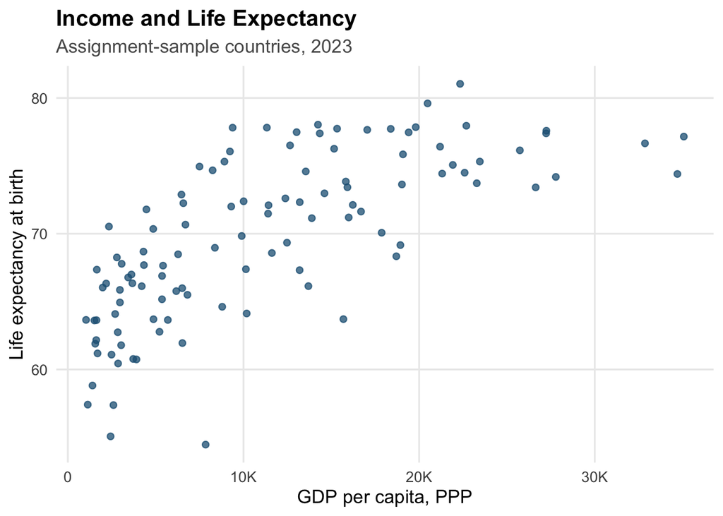

```r
dev |>
  filter(assignment_sample == TRUE & year == 2023) |>
  ggplot(aes(x = gdp_per_capita_ppp, y = life_expectancy)) +
  geom_point(color = hks_blue, alpha = 0.75) +
  scale_x_continuous(labels = scales::label_number(scale_cut = scales::cut_short_scale())) +
  labs(
    x = "GDP per capita, PPP",
    y = "Life expectancy at birth",
    title = "Income and Life Expectancy",
    subtitle = "Assignment-sample countries, 2023"
  )
```

This graph shows an association. It does not prove that GDP per capita causes life expectancy.

## Color and facets

Color can show groups.

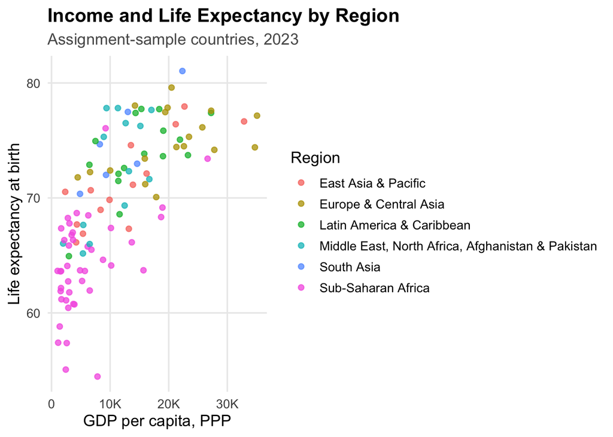

```r
dev |>
  filter(assignment_sample == TRUE & year == 2023) |>
  ggplot(aes(x = gdp_per_capita_ppp, y = life_expectancy, color = region)) +
  geom_point(alpha = 0.75) +
  scale_x_continuous(labels = scales::label_number(scale_cut = scales::cut_short_scale())) +
  labs(
    x = "GDP per capita, PPP",
    y = "Life expectancy at birth",
    color = "Region",
    title = "Income and Life Expectancy by Region",
    subtitle = "Assignment-sample countries, 2023"
  )
```

Facets create small multiples.

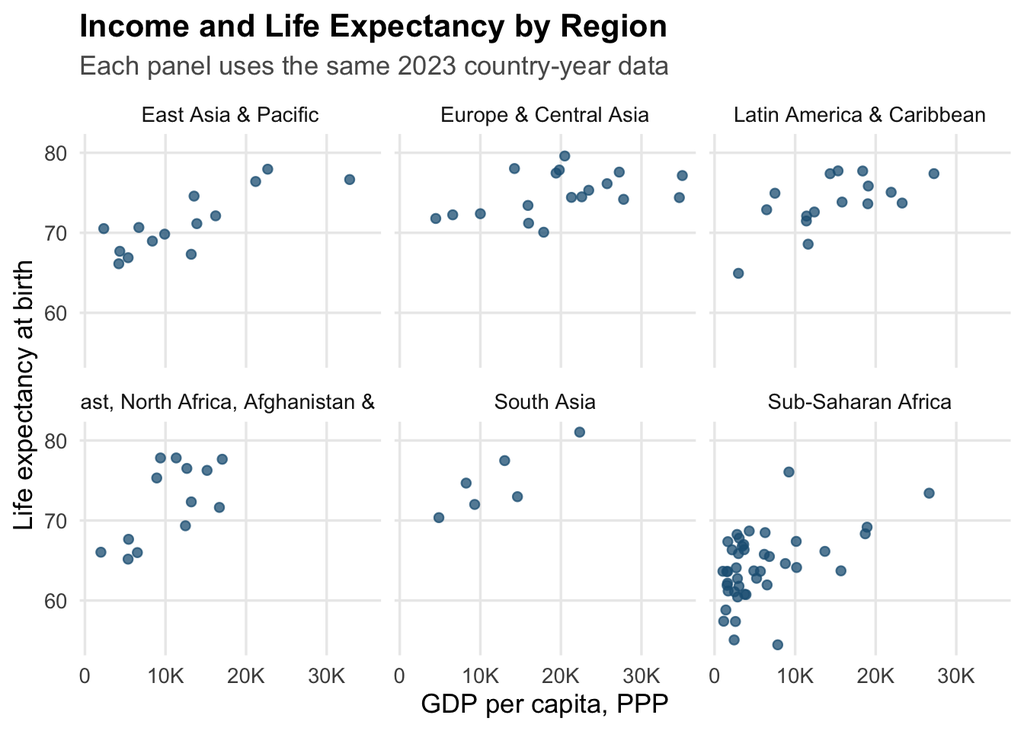

```r
dev |>
  filter(assignment_sample == TRUE & year == 2023) |>
  ggplot(aes(x = gdp_per_capita_ppp, y = life_expectancy)) +
  geom_point(color = hks_blue, alpha = 0.75) +
  scale_x_continuous(labels = scales::label_number(scale_cut = scales::cut_short_scale())) +
  facet_wrap(~region) +
  labs(
    x = "GDP per capita, PPP",
    y = "Life expectancy at birth",
    title = "Income and Life Expectancy by Region",
    subtitle = "Each panel uses the same 2023 country-year data"
  )
```

## Exercises 3: associations

1. Make a scatterplot with GDP per capita on the x-axis and CO2 emissions per capita on the y-axis for assignment-sample countries in 2022 or 2023.

```r
# Write your code here.
```

2. Add color by `region` and clear axis labels.

```r
# Write your code here.
```

3. Write two sentences: one describing the association and one explaining why the graph alone is not causal evidence.

Write your answer here:

## Bar charts

Bar charts can compare values across countries in one year.

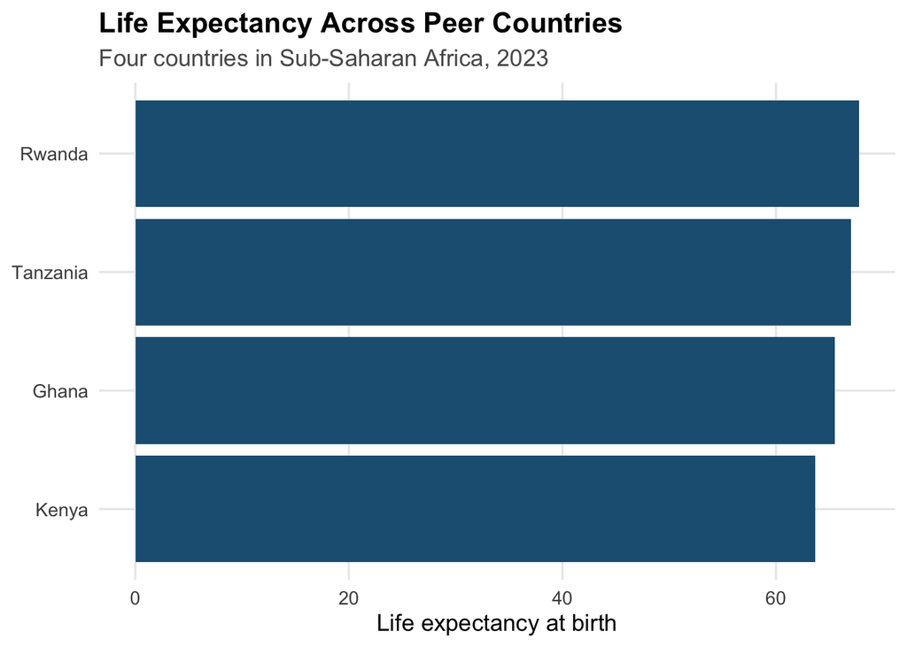

```r
dev |>
  filter(country %in% c("Ghana", "Kenya", "Rwanda", "Tanzania") & year == 2023) |>
  ggplot(aes(x = reorder(country, life_expectancy), y = life_expectancy)) +
  geom_col(fill = hks_blue) +
  coord_flip() +
  labs(
    x = NULL,
    y = "Life expectancy at birth",
    title = "Life Expectancy Across Peer Countries",
    subtitle = "Four countries in Sub-Saharan Africa, 2023"
  )
```

## Optional challenge

If you want more practice, use `ggrepel` to label selected countries in a scatterplot. Keep this optional; it is not required for submission.

```r
install.packages("ggrepel")
library(ggrepel)
```

## AI-use note

If you used AI, write one sentence describing what you asked and how you checked the answer. If you did not use AI, write “I did not use AI for this assignment.”

Write your AI-use note here:

## Before you submit

- Add your name at the top.
- Make sure your plots have meaningful labels.
- Do not make causal claims from descriptive graphs.
- Knit successfully.
- Submit the completed `.Rmd` file to Canvas.